# STA 380, Part 2: Exercises 1

Atindra Bandi

August 10, 2018

# **Probability Practice**

### Part A.

**Given:**

- P(RC) = 0.3
- P(Yes|RC) and P(No|RC) = 0.5
- P(Yes) = 0.65 and P(No) = 0.35

From the first bullet we can say that P(TC) = 1-P(RC) = 0.7. Let us assume that the probability of Yes given its TC i.e. P(Yes|TC) is x.

=> $P(Yes|TC) + P (Yes|RC) = P(Yes)$

=> $x*0.7 + 0.5*0.3 = 0.65$

=> $x = 0.71428$

Thus 71.428% of the people who are truthful clickers answered Yes.

### Part B.

**Given:**

- P(positive-test|disease) = 0.993
- P(negative-test|Nodisease) = 0.9999
- P(disease) = 0.000025

We need to find P(disease|+ve_test). From Bayes theorem -

$P(disease|positive-test) = (P(positive-test|disease)*P(disease))/P(positive-test)$

**Now,** $P(positive-test) = P(disease)*P(positive-test|disease) + P(Nodisease)*P(positive-test|Nodisease)$

```
## [1] 0.1988824
```

Thus, there is 19.88% probability that when someone tests positive they would actually have the disease. The problem with this testing outcome is that the probaility of having a disease even when the test gives positive results is just 19.8%, while the test gives +ve results with a probability of 99.3%. This is because a lot of patients who are not likely to have the disease would also be identified as positives by the test (false psitives) due to highly skewed incidence of the disease.

## **Exploratory Analysis: Green Buildings**

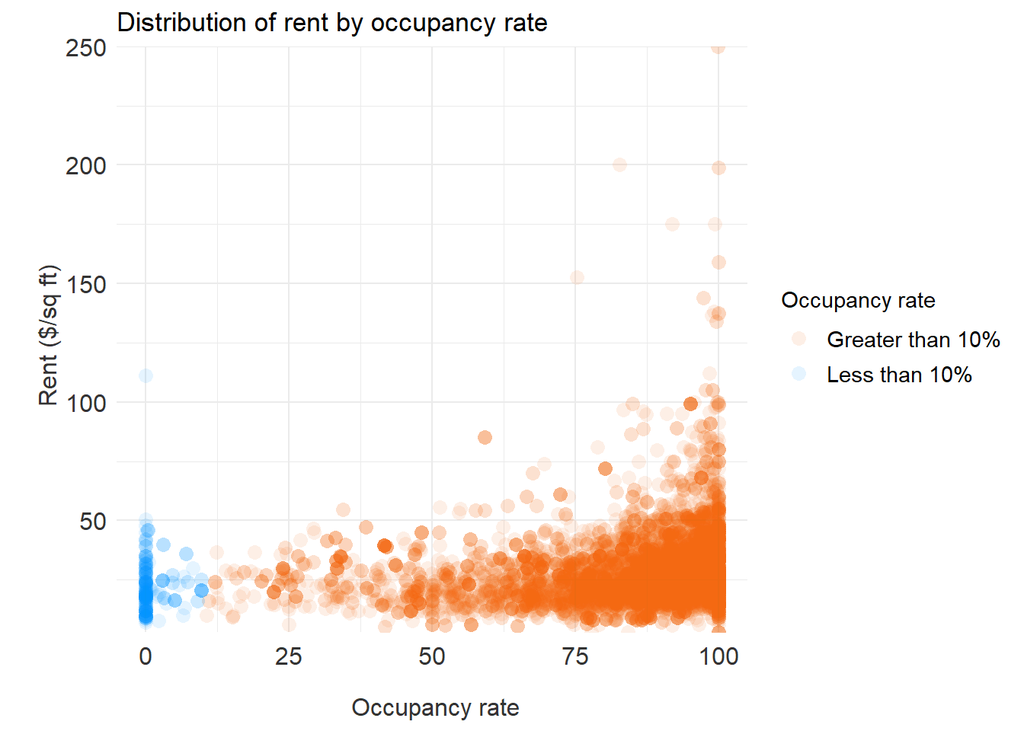

**As we can see from the graph above there are a few houses which have <10% occupancy rate. It does make sense to remove them to keep our analysis robust enough.**

```
## [1] 7679   23
```

**We have 7679 houses in our data set after removing the houses which have <10% occpancy.**

Let us look if there is any missing data in our data set -

```
##     CS_PropertyID           cluster              size           empl_gr
##                 0                 0                 0                73
##              Rent      leasing_rate           stories               age
##                 0                 0                 0                 0
##         renovated           class_a           class_b              LEED
##                 0                 0                 0                 0
##        Energystar      green_rating               net         amenities
##                 0                 0                 0                 0
##       cd_total_07        hd_total07       total_dd_07     Precipitation
##                 0                 0                 0                 0
##         Gas_Costs Electricity_Costs      cluster_rent
##                 0                 0                 0
```

**Overall the data seems to be clean with 73 missing data points in the employment growth rate.**

Now let us try to double check the differnece between the median rent of houses per sq ft of area for the green houses vs. the non-green houses as stated by the statistician.

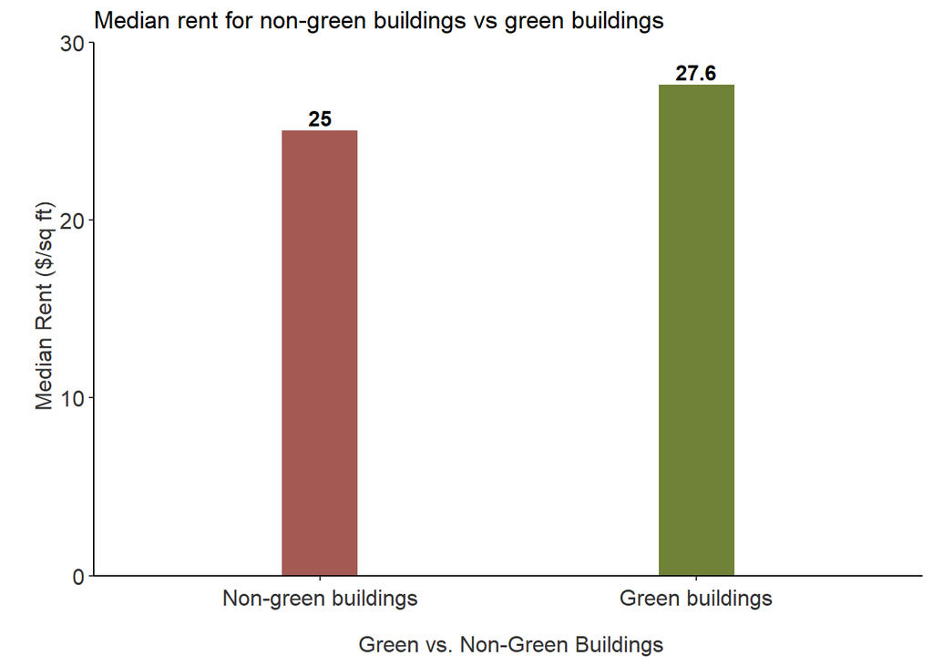

**As we can see from the graph above, it is true that the median rent (per sq ft) of the green buildings is about $2.6 more than that of non-green buildings However there are other factors than just the overall median rent which we should consider to evaluate the cost-benefit analysis of investing in a green house. Below is a summary of some of them which will help us decide better whether we should build a green building or not.**

1. Let’s first evaluate whether the median calculated above is actually correct! The median rent was calculated from all the homes which have >=10% occupancy. However, here are some homes for which the rent does not include the utility costs while most other homes have their utility costs included in quoted rent price. Below is a small table for the same.

```
##    green_rating
##     Non-green buildings Green buildings
##   0                6761             645
##   1                 234              39
```

**From the above table we can say that (234+39) = 273 buildings do not include utilities in the quoted rent. It seems here that the statisticians was including these 2 type of rents in his analysis which. Thus we need to separate out these rents**

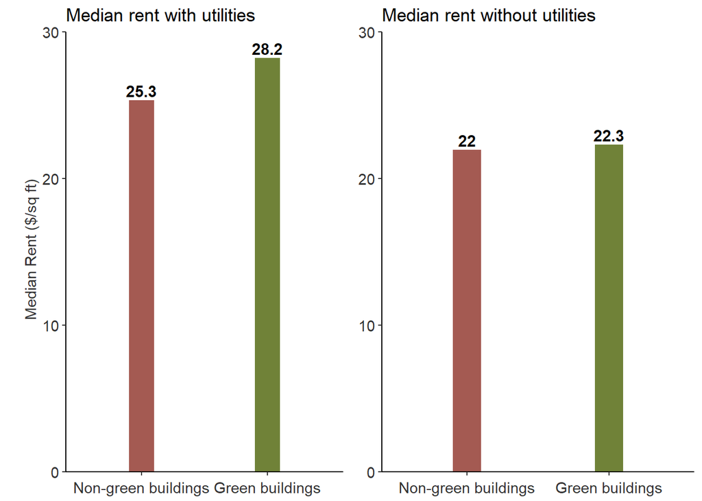

**The left graph shows the median rent for non-green and green buildings when the rent included the utilities, while the right graph shows the same when the rent does not include utilities. Clearly, after separating these rents, green buildings seem to have the median rent of $28.2, which is approximately $3 more than the median rent of non-green buildings. This is more than what the statistician predicted.**

**However, there still exists a big problem. We can’t simply take the median of all the buildings in the US and compare it between green and non-green buildings. We need to look at geographical locations which will significantly impact the building prices. Thus it will be good to look at each of the clusters to understand the difference in prices between green and non-green buuildings.**

However before we process ahead, let us see how the distribution of rent looks like for green buildings .

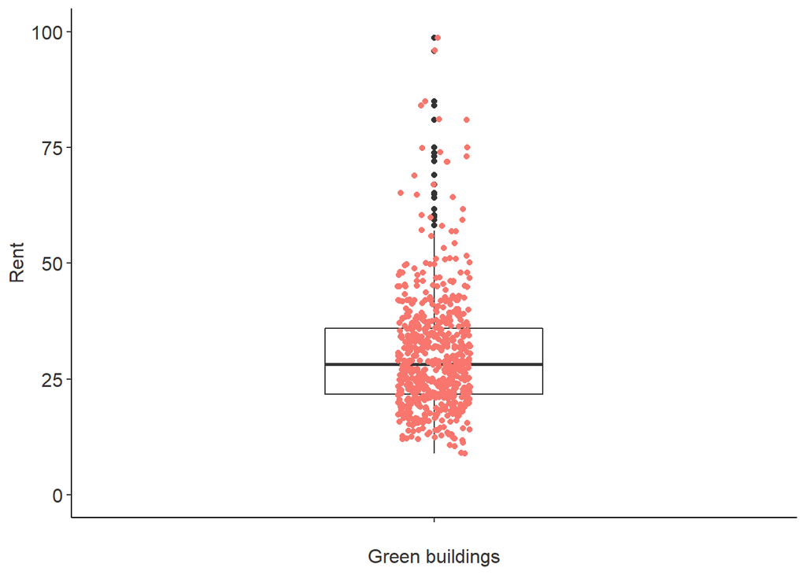

**We can see that there are certainly some outliers and thus we should be careful in only taking median values.**

2. Below we will look at the relationship of the green buildings rent with the average cluster rent.

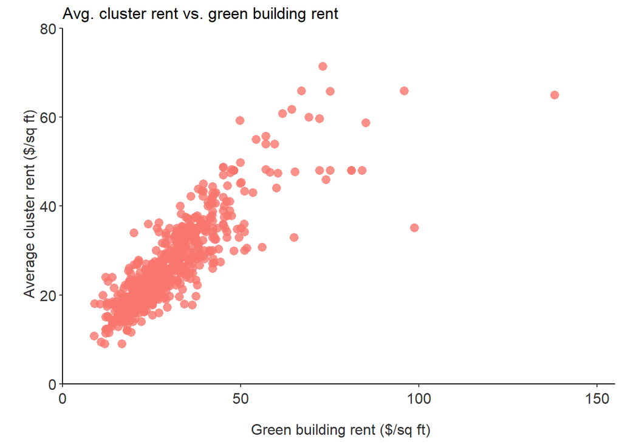

**Clearly based on the above graph there is a positive correlation between the green bjuilding prices and average cluster rent.**

3. Let us now compare how much more or less are the green house prices

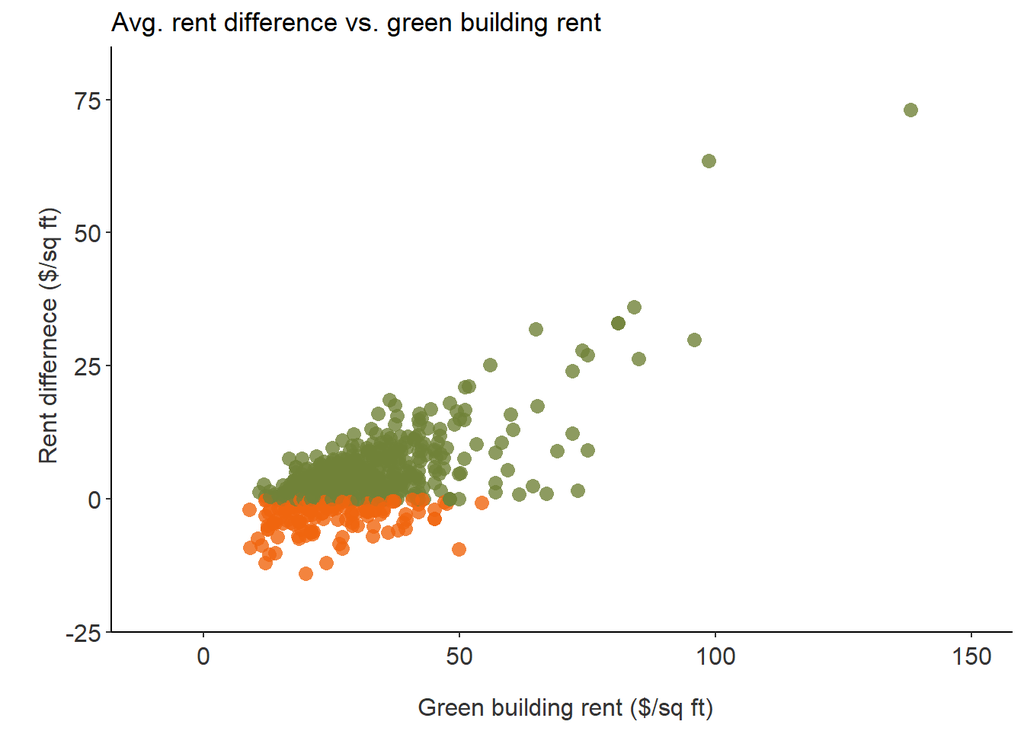

**The above graph shows the difference in the rent of green building and the average cluster rent against the green buildings rent. Ee can observe that a majority of the green buildings have a higher rent than the average cluster rent.**

4. We will now quantify the proportion of green buildings which have a higher rent than the average cluster rent and then try to identify its average magnitude over all the clusters.

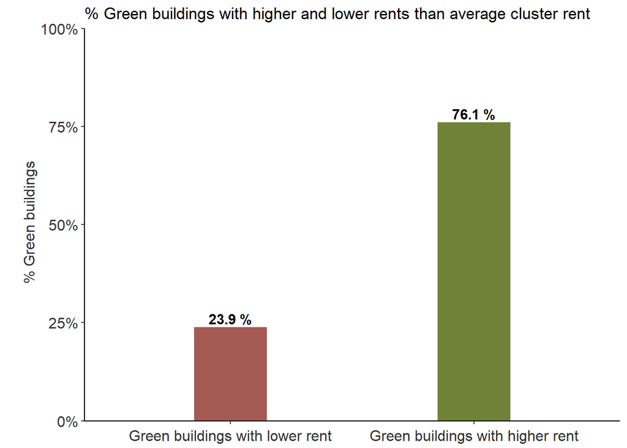

**From the above graph we can observe that three-fourths (76.1%) of the green buildings have a higher rent than the average rent of the cluster.**

5. Finally, let’s look at how different is the overall average of all the green buildings across all the clusters and the average of the clusters

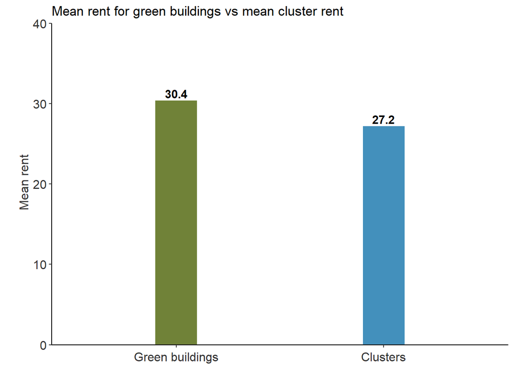

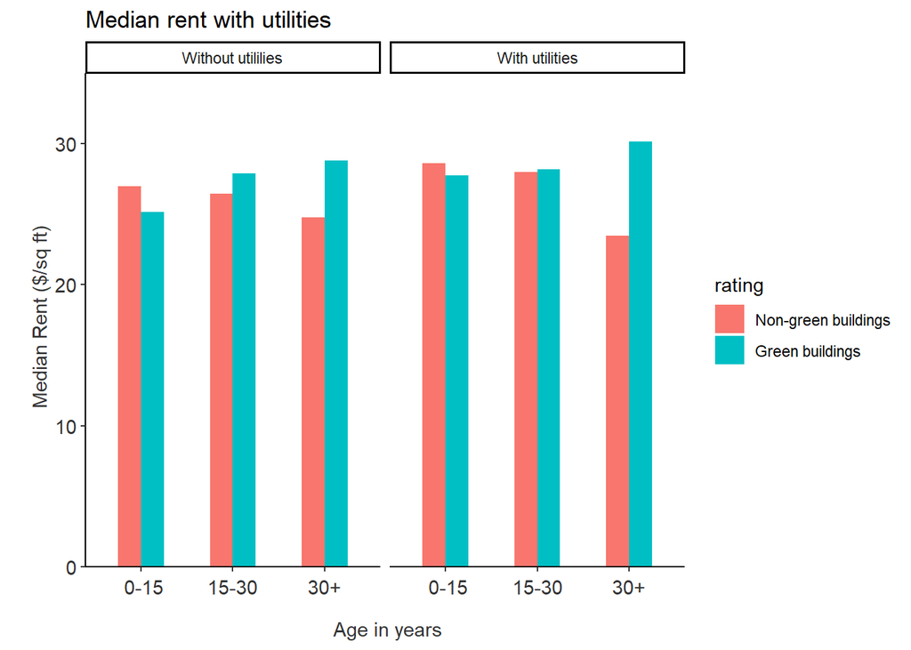

**From the above graphs we can see that non-green buildings are actually expensive for the first 15 years! While the green buildings seem to be more expensive from 15+ years. However, if compare the first 30 years there does not seem to be any major difference between the buildings of similar ages! And thus it would be very difficult to get back the initial investment. Overall, I would recommend to not go ahead with developing the green building.**

## **Bootstrapping**

[output not shown]

[output not shown]

[output not shown]

```
## [1] "SPY" "TLT" "LQD" "EEM" "VNQ"
```

**Let us explore the data starting with SPY (US domestic equities)**

1. Plotting closing price of exchange traded funds over time to get both the good and bad runs of the market

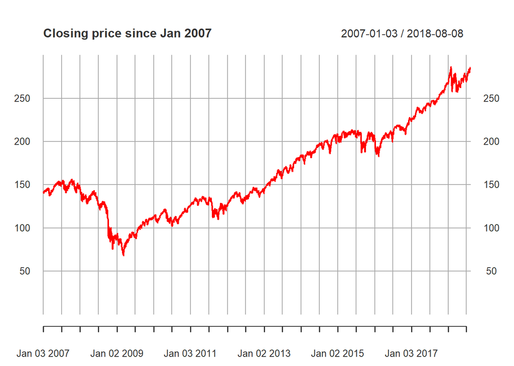

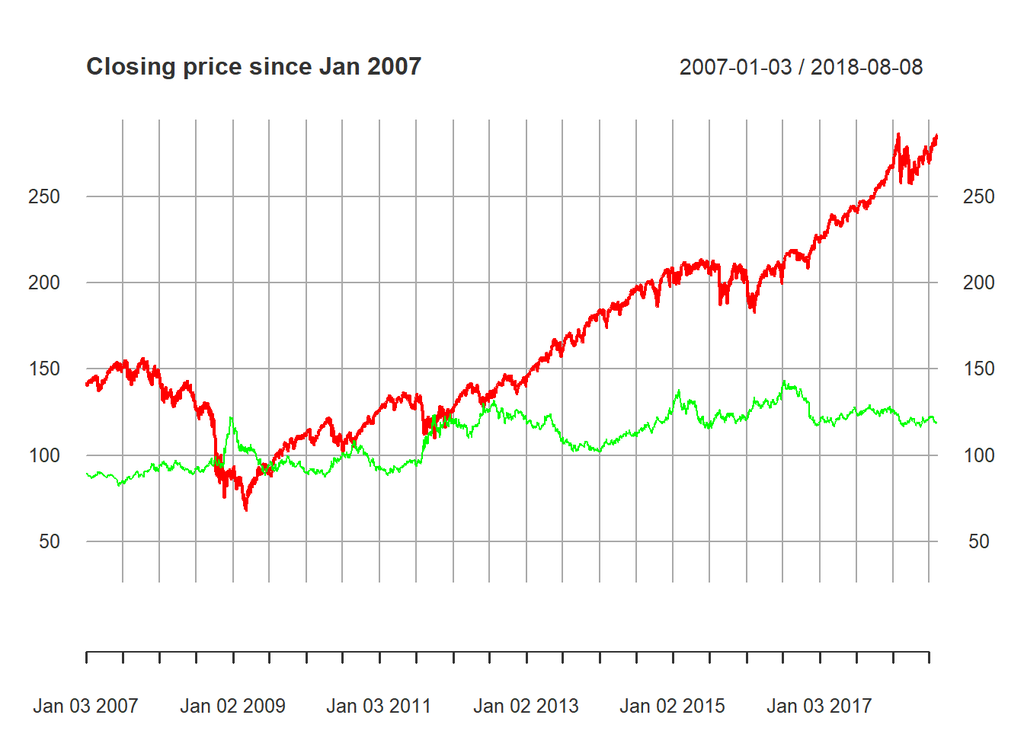

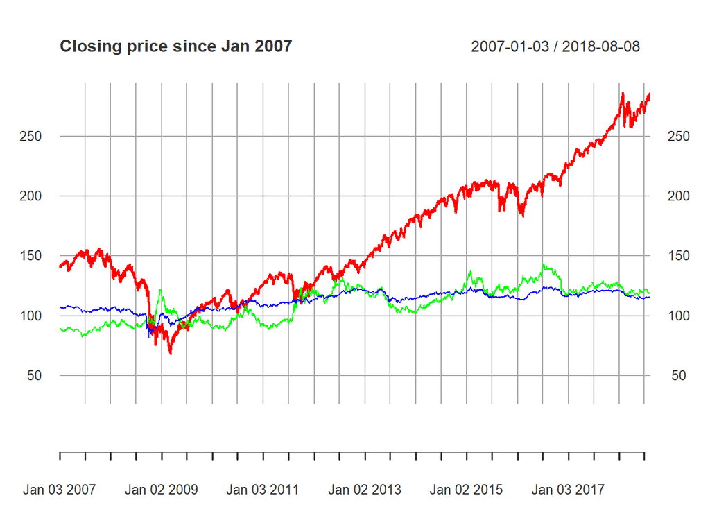

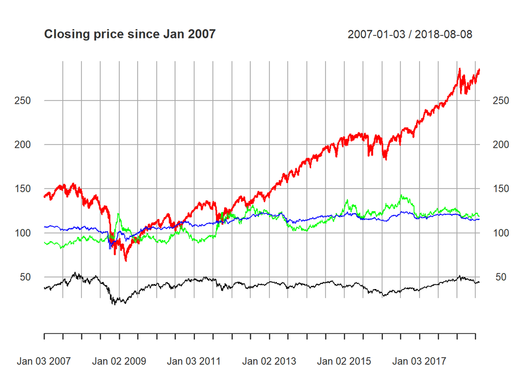

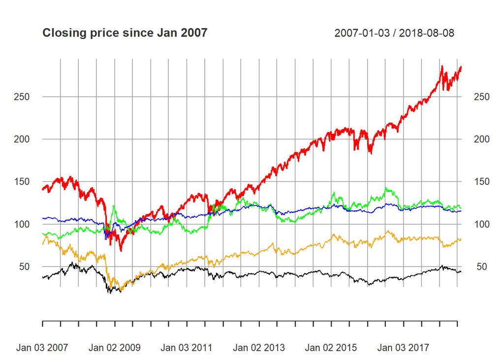

**From the above graph we can see that in 2007 most of the financial markets were performing well and were at a life time high in mid 2007. It was ins 2008 the financial crisis started with a significant slump in 2009. However after that the SPY index has mostly climed up.**

2. Understanding the risk/return values for the 5 traded funds

```
##      Index              ClCl.SPYa            ClCl.TLTa
##  Min.   :2007-01-03   Min.   :-0.0984477   Min.   :-0.0504495
##  1st Qu.:2009-11-24   1st Qu.:-0.0038636   1st Qu.:-0.0052394
##  Median :2012-10-17   Median : 0.0006589   Median : 0.0005553
##  Mean   :2012-10-20   Mean   : 0.0003989   Mean   : 0.0002710
##  3rd Qu.:2015-09-15   3rd Qu.: 0.0056254   3rd Qu.: 0.0056656
##  Max.   :2018-08-08   Max.   : 0.1451977   Max.   : 0.0516616
##                       NA's   :1            NA's   :1
##    ClCl.LQDa            ClCl.EEMa            ClCl.VNQa
##  Min.   :-0.0911111   Min.   :-0.1616620   Min.   :-0.1951372
##  1st Qu.:-0.0019182   1st Qu.:-0.0085267   1st Qu.:-0.0069231
##  Median : 0.0004104   Median : 0.0008056   Median : 0.0006617
##  Mean   : 0.0002066   Mean   : 0.0009985   Mean   : 0.0004095
##  3rd Qu.: 0.0024758   3rd Qu.: 0.0092223   3rd Qu.: 0.0077793
##  Max.   : 0.0976772   Max.   : 1.8891250   Max.   : 0.1700654
##  NA's   :1            NA's   :1            NA's   :1
```

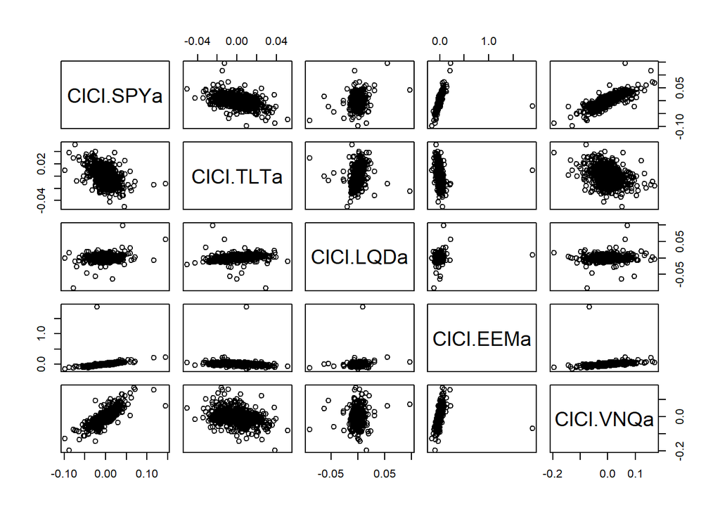

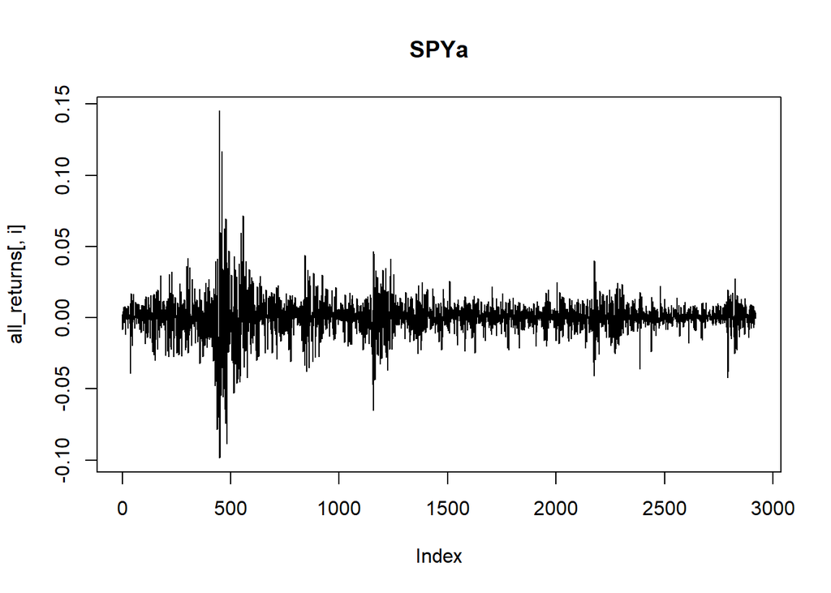

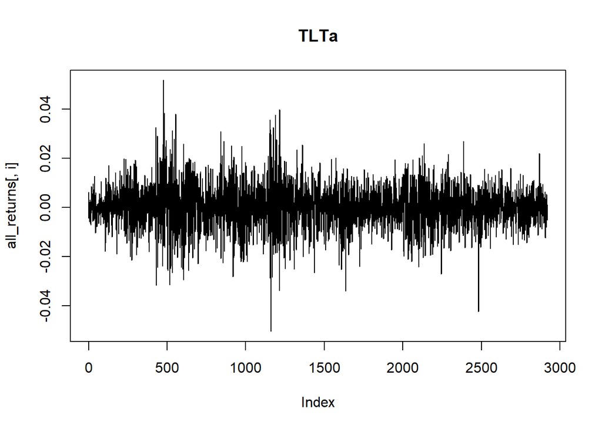

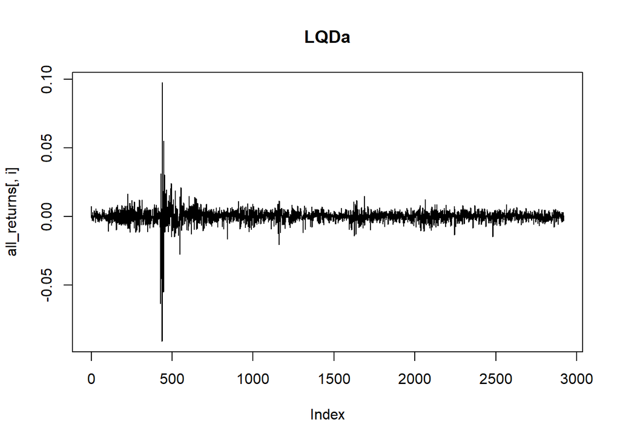

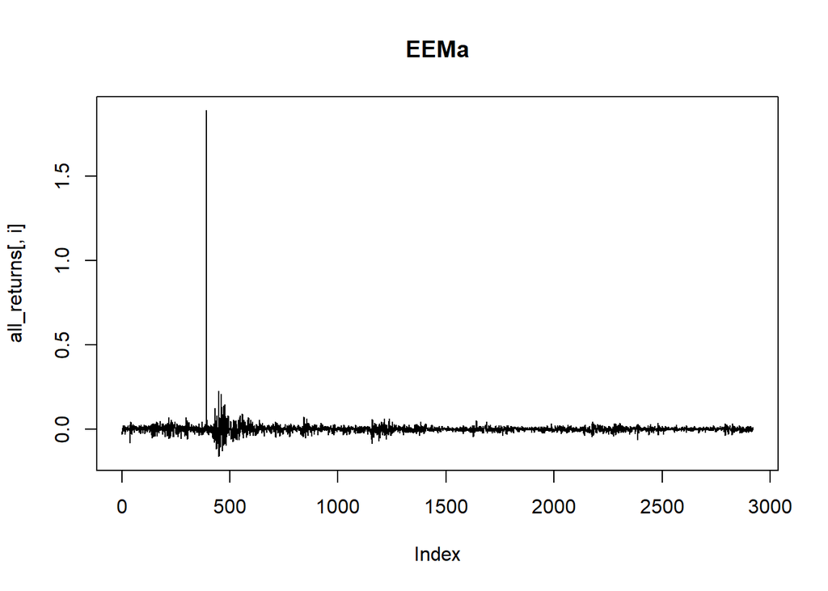

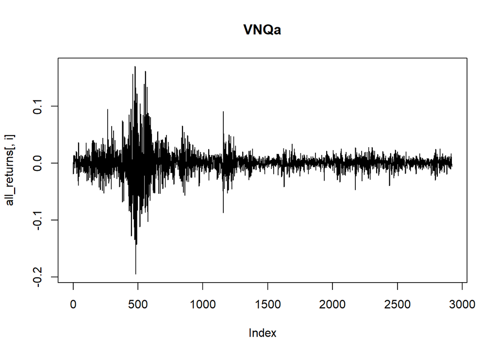

```
##    ClCl.SPYa            ClCl.TLTa            ClCl.LQDa
##  Min.   :-0.0984477   Min.   :-0.0504495   Min.   :-0.0911111
##  1st Qu.:-0.0038636   1st Qu.:-0.0052394   1st Qu.:-0.0019182
##  Median : 0.0006589   Median : 0.0005553   Median : 0.0004104
##  Mean   : 0.0003989   Mean   : 0.0002710   Mean   : 0.0002066
##  3rd Qu.: 0.0056254   3rd Qu.: 0.0056656   3rd Qu.: 0.0024758
##  Max.   : 0.1451977   Max.   : 0.0516616   Max.   : 0.0976772
##    ClCl.EEMa            ClCl.VNQa
##  Min.   :-0.1616620   Min.   :-0.1951372
##  1st Qu.:-0.0085267   1st Qu.:-0.0069231
##  Median : 0.0008056   Median : 0.0006617
##  Mean   : 0.0009985   Mean   : 0.0004095
##  3rd Qu.: 0.0092223   3rd Qu.: 0.0077793
##  Max.   : 1.8891250   Max.   : 0.1700654
```

**Based on the above summary and graphs plotted we can identify the volatile and safer funds. If we look at the difference in max and min returns, we will see that EEMa and VNQa have the highest return, while SPYa, TLTa and LQDa seem to be safer from the same analysis.**

[output not shown]

[output not shown]

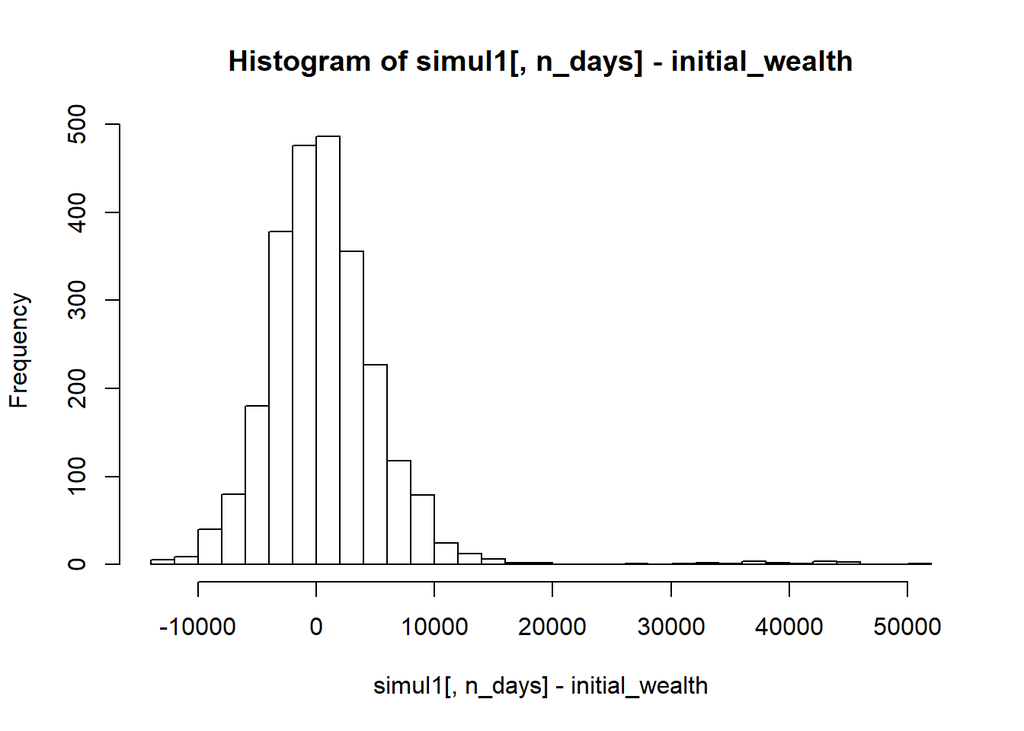

```
##       5%
## 6119.365
```

**Thus the value at risk @5% for the first portfolio is 6119.3652777**

Safer investment than the even split

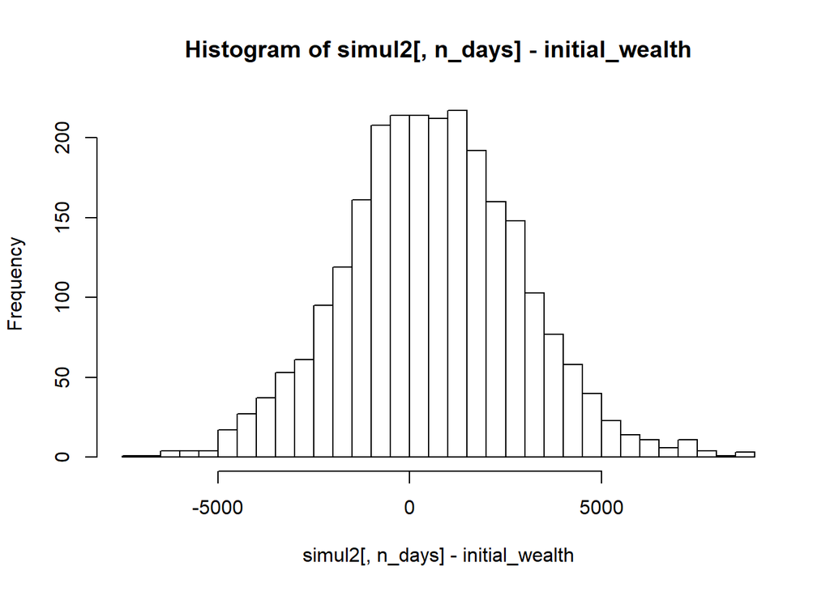

```
##       5%
## 3175.961
```

**The value at risk @5% for the safer portfolio is 3175.9612965**

Aggressive investment than the even split

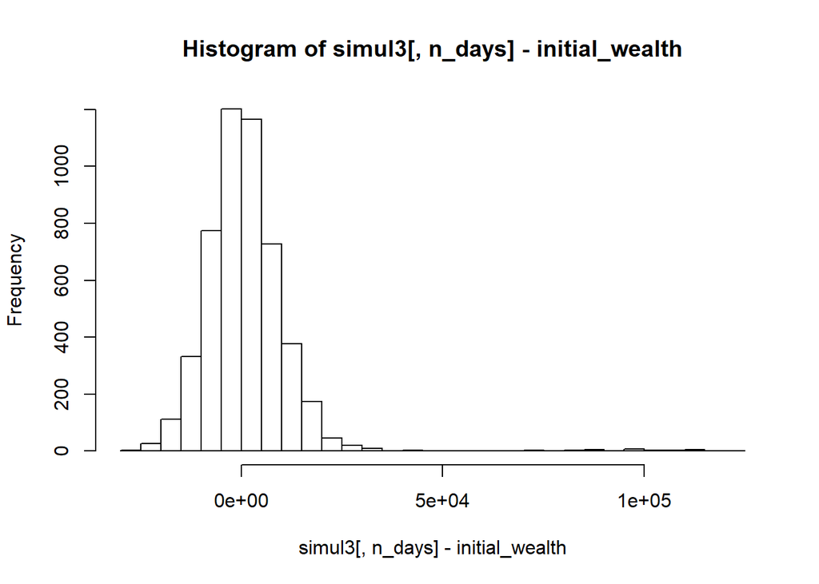

```
##      5%
## 12728.2
```

Compare the 3 portfolios

```
##         Portfolio Type   Average Profit              VAR
## 1       even_portfolio 100791.129901285 6119.36527767249
## 2      safer_portfolio 100604.242242177 3175.96129645449
## 3 aggressive_portfolio 101105.507598815  12728.202515057
```

**Overall after analyzing the VAR for the 3 portfolios we can say that the aggressive portfolio does have a higher VAR, however it also has a higher return. So, the investor needs to take a decision based on his/her risk apetite. If they are willing to take a higher risk they can invest in EMEa**

## **Market Segmentation**

```
## [1] 7882   37
```

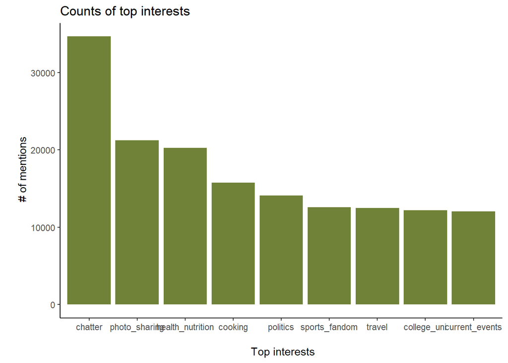

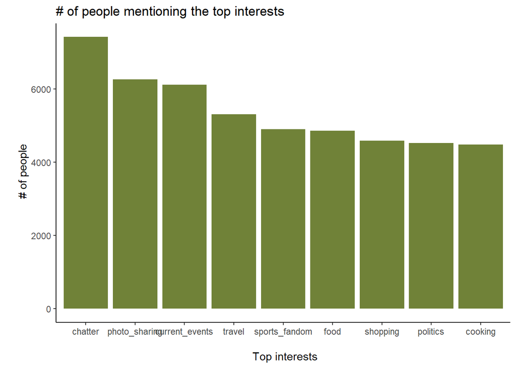

**Based on the 2 plots above it seems that there have been a lot of mentions of photo-sharing, health nutrition, sports fandom, travel, current events and college_university. We should however look whether there are any interesting correlations among these variables to beter profile the segments.**

Below we will see the correlation between different variables

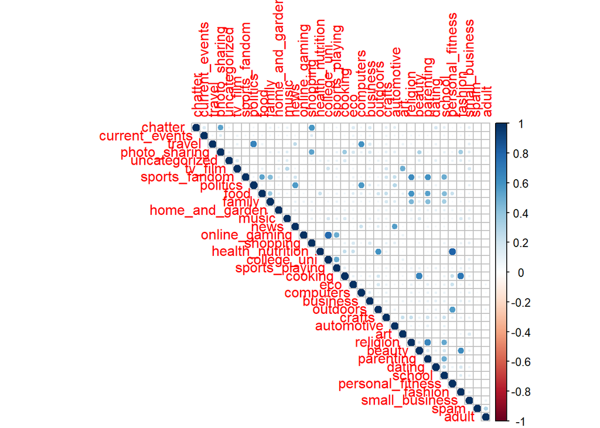

**Based on the correlation matrix we find the following variables correlated among themselves. This means that the customer segments could be defined using these correlated variables -**

**We will explore these below through clustering and try to identify key segments for the company.**

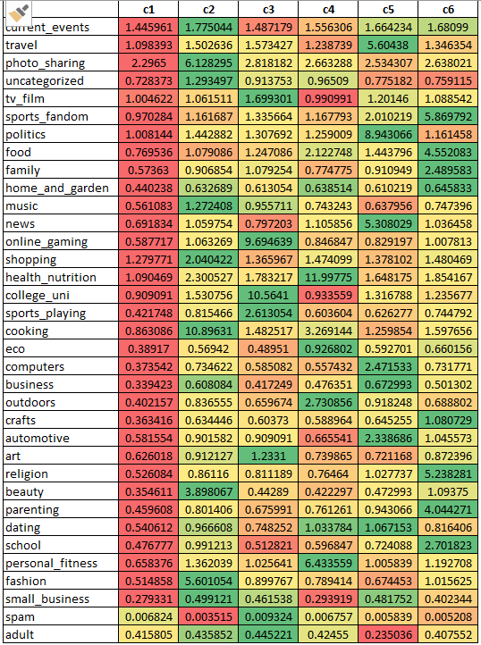

**The table above shows the value of the cluster centers for each cluster and each interest. We can see interesting similarities between the 6 clusters. Below is the description for each of them.**